# Monthly Budgeting Information

Beka

8/11/2021

# Monthly Operating Income and Expenses, BEI January - July 2021

## Monthly Expenses

- For an overview of expenses by month and category see [Monthly Expense Datatable](https://rpubs.com/BEI_BB/monthly_expenses)
  - this table provides an overview of all expenses, sorted by expense category and month.
- For a summary of monthly expenses by category for the period of January - July 2021 see [Monthly Expenses by Category](https://rpubs.com/BEI_BB/expenses_summary)
  - this table provides information on the minimum, average, and maximum amounts spent in each category, along with the standard error around the estimate of the average amount spent.

### Monthly Expenses Graphs

#### All expenses, including farm lease expense which includes owners draws

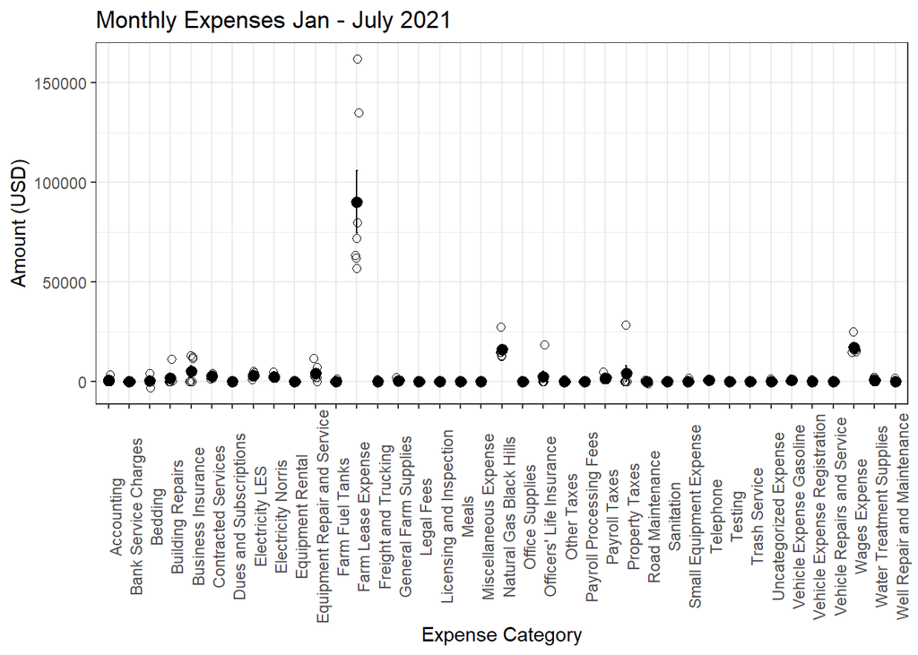

#### All expenses minus farm lease expenses

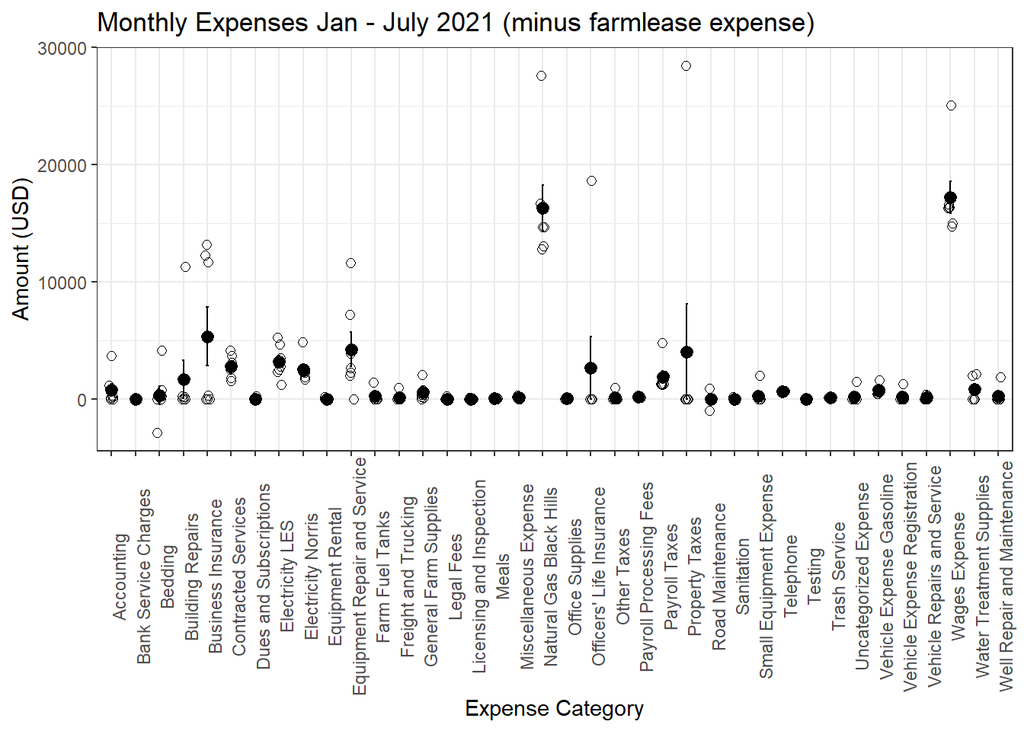

#### All expenses below $10k

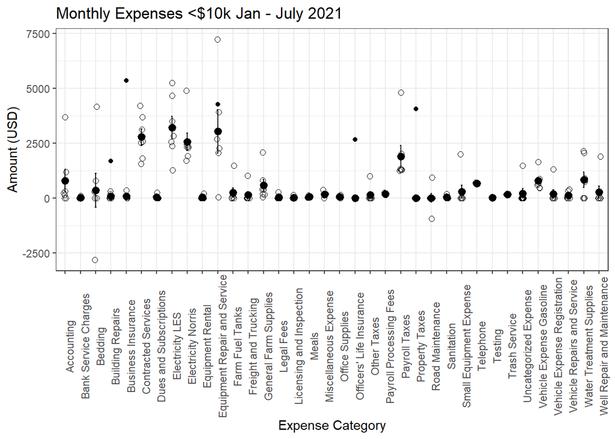

#### Average Monthly Expenses:

```
## [1] 158640.3
```

- **NOTE** Average expenses shown here do not include depreciation (total of 45500 over the period January - July 2021) or interest expense (121.36 total over the period of January - July 2021).

## Monthly Income

- For an overview of income by month and category see [Monthly Income Datatable](https://rpubs.com/BEI_BB/monthly_income)
  - this table shows income sorted by month and income category.
- For summary statistics on monthly income by category (for the period of January - July 2021) see [Average Income by Category](https://rpubs.com/BEI_BB/average_income)
  - this table provides information on the minimum, average, and maximum amounts of income in each category, along with the standard error around the estimate of the average.

### Monthly Income Graph

#### All income, minus ‘other’ category ($44,776.93 total, from tax return and deposit from Hippo)

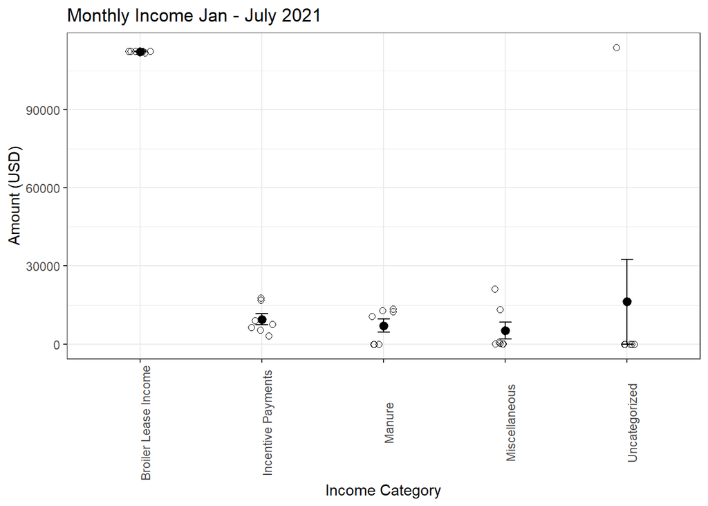

#### Average monthly income (minus the ‘other’ category):

```
## [1] 150373.1
```

#### Average monthly income less expenses (excluding the ‘other’ income and ‘other’ expenses):

```
## [1] -8267.261
```

#### Total ‘other’ income less ‘other’ expenses for the period January - July 2021: **-844.43**

### Spending projection

- **NOTE** this is simply the average spent over the period January - July 2021

| Category_Name | average | sd |
| --- | --- | --- |
| Farm Lease Expense | 90204.98 | 41235.19 |
| Wages Expense | 17217.27 | 3540.64 |
| Natural Gas Black Hills | 16316.16 | 5141.39 |
| Business Insurance | 5362.38 | 6594.30 |
| Equipment Repair and Service | 4264.15 | 3934.31 |
| Property Taxes | 4064.69 | 10754.15 |
| Electricity LES | 3209.08 | 1381.08 |
| Contracted Services | 2782.16 | 959.26 |
| Officers' Life Insurance | 2667.59 | 7057.77 |
| Electricity Norris | 2560.12 | 1067.57 |

[output cut: 29 more lines]